# ALMA Science Archive Query Tools

### **Martina Torsello**

#### **The Birth of Solar Systems Summer School**

#### **3 March 2025**

## Query Tools Notebook

This notebook is designed to help you learn how to utilize query tools within the [ALMA Science Archive (ASA)](https://almascience.eso.org/aq/).

### How to Use

Each cell can be executed by pressing `Shift`+`Enter`, you may enter your attempts in the empty cells and create new cells by clicking the `+Code` button.

You can run it using Google Colab or Jupyter Notebook in your own python/conda environment.

**To open the notebook in Colab:** https://colab.research.google.com/github/martitors/PPD_School_2025/blob/main/Query_tutorial_PPD.ipynb

**To download the notebook and work with it in your local station:** https://github.com/martitors/PPD_School_2025/blob/main/Query_tutorial_PPD.ipynb

## Parts Overview

In this notebook we will see three of the most popular query tools:

### Part 1. pyVO

### Part 2. astroquery

### Part 3. ALminer

### Part 4. Exercise

## Packages installation

### **Google Colab**

If you are using Colab, the installation of the different packages will be done through *pip*.

```python
import sys
moduleList = sys.modules

if 'google.colab' in moduleList:

    ! pip install https://github.com/emerge-erc/ALminer/archive/refs/heads/main.zip
```

### **Local environment**

Otherwise, if you are running this notebook on the your local machine using jupyter, you should install all the packages in advance on your own conda/pyhton environment. After you have activate your environment, you can execute the following lines:

#### **Download scipy and ALminer (pyVO and astroquery are automatically installed via ALminer dependencies)

**BEWARE:** You should download the 'bleeding edge' from github and not the classic *pip install alminer*. Some functions (i.e. Splatalogue) currently only work in the development version of this packages.

`pip install scipy https://github.com/emerge-erc/ALminer/archive/refs/heads/main.zip`

# Part 1. pyVO

**pyVO** (Python Virtual Observatory) is a Python library designed to access and query astronomical data through the Virtual Observatory (VO).

- Officially supported by the ALMA archive developers.
- Offers a simple interface to query VO services and retrieve astronomical data from them.
- It facilitates tasks such as searching for specific observations, accessing metadata, and downloading data files for analysis.

## Set-up

```python
import pyvo
import pandas as pd

service = pyvo.dal.TAPService("https://almascience.eso.org/tap")

# If the ESO archive is down, you may use the NRAO/NAOJ mirrors:
# service = pyvo.dal.TAPService("https://almascience.nrao.edu/tap")
# service = pyvo.dal.TAPService("https://almascience.nao.ac.jp/tap")
```

## Resources

- The language used by the IVOA to represent astronomy queries posted to VO services: [The Astronomical Data Query Language (ADQL)](https://www.ivoa.net/documents/ADQL/20180112/PR-ADQL-2.1-20180112.html).
- Examples on using pyVO to query the ALMA archive: [Notebooks on the ALMA Science Portal](https://almascience.eso.org/alma-data/archive/archive-notebooks).

## Query Standart Format

```python
query = f"""

         """
```

#### Quering options:

- `SELECT`: The columns you want to retrieve from the table.
- `WHERE`: The constraints on the data you want to retrieve.
- `FROM`: Specifies the table or catalog from which you want to retrieve data.
- `INTERSECT`: The results should match both conditions specified.
- `JOIN`: Join operation between two tables.
- `ORDER BY`: The column(s) by which the results should be sorted.
- `LIMIT`: The maximum number of results to return.
- `FORMAT`: The format in which you want the results to be returned (e.g., VOTable, CSV, JSON).

## Get all available column names

```python
# Query the metadata
metadata_query = """ SELECT column_name, unit, description
                     FROM TAP_SCHEMA.columns """

TAP_metadata = service.search(metadata_query)

# Convert in pandas dataframe
TAP_metadata_pd = pd.DataFrame(TAP_metadata).set_index('column_name')

print(TAP_metadata_pd.index.to_list())
```

```
['source_names', 'm_ra', 'm_ra_uncertainty', 'm_dec', 'm_dec_uncertainty', 'm_frequency', 'm_flux', 'm_flux_uncertainty', 'm_origin', 'm_degree', 'm_degree_uncertainty', 'm_angle', 'm_angle_uncertainty', 'm_date_observed', 'm_frequency_support_display', 's_ra_deg', 's_ra_deg_uncertainty', 's_dec_deg…
```

## Get information about a column

```python
column = 'frequency'

#Print the column name
print("\033[1mColumn: \033[0m", column )

# Get the description of a given column
print("\n\033[1mDescription: \033[0m",
      TAP_metadata_pd.loc[ column , 'description'])

# Get the units of a given column
print("\n\033[1mUnits: \033[0m",
      TAP_metadata_pd.loc[ column , 'unit'])
```

```
Column:  frequency

Description:  Observed (tuned) reference frequency on the sky.

Units:  GHz
```

## Pandas Dataframe

PyVO provides the capability to display tables in **Pandas** format, which is particularly useful for data visualization.

### Pandas table display set-up

```python
pd.set_option('display.max_rows', 4)
pd.set_option('display.max_columns', 6)
```

**BEWARE:** You can choose to display all the rows or columns using `pd.set_option(..., None)`, but this may overload your notebook and crash the kernel!

## Query by coordinates

#### **RA** = 67.910462 , **Dec** = 18.232739, **Search radius** = 0.005 degrees:

```python
query = f"""
        SELECT *
        FROM ivoa.obscore
        WHERE INTERSECTS(
                CIRCLE( 'ICRS', 67.910462, 18.232739, 0.005)
                ,s_region ) =1
        """
q_results = service.search(query).to_table().to_pandas()
q_results
```

|  | obs_publisher_did | obs_collection | facility_name | ... | proposal_authors | sensitivity_10kms | lastModified |
| --- | --- | --- | --- | --- | --- | --- | --- |
| 0 | ADS/JAO.ALMA#2011.0.00005.E | ALMA | JAO | ... |  | 7.265467 | 2024-08-21T18:10:02.819 |
| 1 | ADS/JAO.ALMA#2011.0.00005.E | ALMA | JAO | ... |  | 6.986938 | 2024-08-21T18:10:02.819 |
| ... | ... | ... | ... | ... | ... | ... | ... |
| 335 | ADS/JAO.ALMA#2016.1.00115.S | ALMA | JAO | ... | Muto, Takayuki; Tsukagoshi, Takashi; Hanawa, T... | 0.576380 | 2024-08-21T18:10:02.819 |
| 336 | ADS/JAO.ALMA#2016.1.00115.S | ALMA | JAO | ... | Muto, Takayuki; Tsukagoshi, Takashi; Hanawa, T... | 0.593098 | 2024-08-21T18:10:02.819 |

337 rows × 73 columns

## Query by a list of coordinates

```python
ra_list = [ 67.910462, 165.466277]
dec_list = [ 18.232739, -34.704758 ]
radius = 0.005

coord_conditions = [f"""INTERSECTS(CIRCLE('ICRS',{c[0]},{c[1]},{radius})
                    ,s_region)=1""" for c in zip(ra_list, dec_list)]

query = f"""
        SELECT *
        FROM ivoa.obscore
        WHERE {" OR ".join(coord_conditions)}"""

q_results = service.search(query).to_table().to_pandas()
q_results
```

|  | obs_publisher_did | obs_collection | facility_name | ... | proposal_authors | sensitivity_10kms | lastModified |
| --- | --- | --- | --- | --- | --- | --- | --- |
| 0 | ADS/JAO.ALMA#2011.0.00340.S | ALMA | JAO | ... | Oberg, Karin; Bergin, Edwin; Blake, Geoffrey; ... | 2.395409 | 2024-08-21T18:10:02.819 |
| 1 | ADS/JAO.ALMA#2011.0.00340.S | ALMA | JAO | ... | Oberg, Karin; Bergin, Edwin; Blake, Geoffrey; ... | 2.396412 | 2024-08-21T18:10:02.819 |
| ... | ... | ... | ... | ... | ... | ... | ... |
| 753 | ADS/JAO.ALMA#2023.1.00515.S | ALMA | JAO | ... | Looney, Leslie; Lin, Zhe-Yu Daniel; Yang, Haif... | 0.504474 | 2024-08-21T18:10:02.819 |
| 754 | ADS/JAO.ALMA#2023.1.00515.S | ALMA | JAO | ... | Looney, Leslie; Lin, Zhe-Yu Daniel; Yang, Haif... | 0.535628 | 2024-08-21T18:10:02.819 |

755 rows × 73 columns

## Query by astropy coordinates

```python
import astropy
coordinates = astropy.coordinates.SkyCoord.from_name("HL Tau")
ra = float(coordinates.ra.degree)
dec = float(coordinates.dec.degree)

query = f"""
            SELECT *
            FROM ivoa.obscore
            WHERE INTERSECTS(CIRCLE('ICRS',{ra},{dec},0.005),
            s_region)=1
        """
q_results = service.search(query).to_table().to_pandas()
q_results
```

|  | obs_publisher_did | obs_collection | facility_name | ... | proposal_authors | sensitivity_10kms | lastModified |
| --- | --- | --- | --- | --- | --- | --- | --- |
| 0 | ADS/JAO.ALMA#2013.1.00355.S | ALMA | JAO | ... | Looney, Leslie; Crutcher, Richard; Fernandez-L... | 0.977043 | 2024-08-21T18:10:02.819 |
| 1 | ADS/JAO.ALMA#2013.1.00355.S | ALMA | JAO | ... | Looney, Leslie; Crutcher, Richard; Fernandez-L... | 0.886412 | 2024-08-21T18:10:02.819 |
| ... | ... | ... | ... | ... | ... | ... | ... |
| 335 | ADS/JAO.ALMA#2023.1.00515.S | ALMA | JAO | ... | Looney, Leslie; Lin, Zhe-Yu Daniel; Yang, Haif... | 0.504474 | 2024-08-21T18:10:02.819 |
| 336 | ADS/JAO.ALMA#2023.1.00515.S | ALMA | JAO | ... | Looney, Leslie; Lin, Zhe-Yu Daniel; Yang, Haif... | 0.535628 | 2024-08-21T18:10:02.819 |

337 rows × 73 columns

## Display the output query

### Display all the column names in the output query:

```python
print(q_results.columns)
```

```
Index(['obs_publisher_did', 'obs_collection', 'facility_name',
       'instrument_name', 'obs_id', 'dataproduct_type', 'calib_level',
       'collections', 'target_name', 's_ra', 's_dec', 's_fov', 's_region',
       's_xel1', 's_xel2', 'em_xel', 't_xel', 'pol_xel', 's_resolution',
       't_min', 't_max', 't_exptime', 't_resolution', 'em_min', 'em_max',
       'em_res_power', 'pol_states', 'cont_sensitivity_bandwidth', 'pwv',
       'group_ous_uid', 'member_ous_uid', 'asdm_uid', 'obs_title', 'type',
       'scan_intent', 'science_observation', 'spatial_scale_max', 'qa2_passed',
       'bib_reference', 'science_keyword', 'scientific_category', 'pi_userid',
       'pi_name', 'spectral_resolution', 'o_ucd', 'access_url',
       'access_format', 'access_estsize', 'proposal_id', 'data_rights',
       'gal_longitude', 'gal_latitude', 'band_list', 'em_resolution',
       'bandwidth', 'antenna_arrays', 'is_mosaic', 'obs_release_date',
       'spatial_resolution', 'frequency_support', 'frequency',
       'velocity_resolution', 'obs_creator_name', 'pub_title', 'first_author',
       'authors', 'pub_abstract', 'publication_year', 'proposal_abstract',
       'schedblock_name', 'proposal_authors', 'sensitivity_10kms',
       'lastModified'],
      dtype='object')
```

### Query only specific columns:

```python
query = f"""
        SELECT proposal_id, target_name, s_ra, s_dec, frequency,
               spatial_resolution, band_list
        FROM ivoa.obscore
        WHERE INTERSECTS(
                CIRCLE( 'ICRS', 165.466277, -34.704758 ,0.005)
                ,s_region ) =1
        """
q_results = service.search(query).to_table().to_pandas()
q_results
```

|  | proposal_id | target_name | s_ra | ... | frequency | spatial_resolution | band_list |
| --- | --- | --- | --- | --- | --- | --- | --- |
| 0 | 2022.1.00840.S | TW_Hya | 165.465744 | ... | 113.188934 | 0.955078 | 3 |
| 1 | 2022.1.00840.S | TW_Hya | 165.465744 | ... | 113.503931 | 0.955078 | 3 |
| ... | ... | ... | ... | ... | ... | ... | ... |
| 416 | 2011.0.00001.SV | TW Hya | 165.466276 | ... | 345.823706 | 1.670760 | 7 |
| 417 | 2011.0.00001.SV | TW Hya | 165.466276 | ... | 343.745185 | 1.670760 | 7 |

418 rows × 7 columns

### Display the unique proposal IDs associated with the search results:

```python
print(q_results['proposal_id'].unique())
```

```
['2022.1.00840.S' '2022.1.00887.S' '2022.1.01553.S' '2011.0.00399.S'
 '2011.0.00340.S' '2012.1.00422.S' '2012.1.01012.S' '2013.1.00114.S'
 '2012.1.00400.S' '2013.1.00196.S' '2013.1.00198.S' '2013.1.00902.S'
 '2013.1.00527.S' '2013.1.00387.S' '2013.1.01397.S' '2013.1.00192.S'
 '2015.1.00686.S' '2015.A.00005.S' '2015.1.00308.S' '2015.1.00845.S'
 '2015.1.00139.S' '2015.1.01597.S' '2015.1.01137.S' '2016.1.00592.S'
 '2016.1.01495.S' '2016.1.00842.S' '2016.1.00440.S' '2016.1.01375.S'
 '2016.1.00229.S' '2016.1.00464.S' '2016.1.00311.S' '2016.1.01046.S'
 '2016.1.00629.S' '2016.1.01399.S' '2017.1.00520.S' '2016.1.00173.S'
 '2017.1.01587.S' '2017.1.01199.S' '2017.1.01056.S' '2018.1.01644.S'
 '2018.1.00167.S' '2018.1.00980.S' '2018.1.00810.S' '2018.A.00021.S'
 '2018.1.00460.S' '2018.1.01218.S' '2018.1.01173.S' '2019.1.00769.S'
 '2019.1.01153.S' '2019.1.01177.S' '2011.0.00001.SV']
```

### Plot the right ascension and declination of all fields in the search:

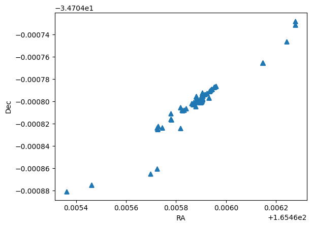

```python
import matplotlib.pyplot as plt

x,y = q_results['s_ra'] ,q_results['s_dec']
plt.scatter( x , y, marker= '^' )
plt.xlabel( 'RA' )
plt.ylabel( 'Dec' )
plt.show()
```

## Query by Target Name

```python
query = f"""
            SELECT proposal_id, target_name, s_ra, s_dec, frequency,
                   spatial_resolution
            FROM ivoa.obscore
            WHERE target_name like '%HL%Tau%'
        """
q_results = service.search(query).to_table().to_pandas()
q_results
```

|  | proposal_id | target_name | s_ra | s_dec | frequency | spatial_resolution |
| --- | --- | --- | --- | --- | --- | --- |
| 0 | 2022.1.00905.S | HL_Tau | 67.910491 | 18.232638 | 173.502610 | 0.048865 |
| 1 | 2022.1.00905.S | HL_Tau | 67.910491 | 18.232638 | 183.305780 | 0.048865 |
| ... | ... | ... | ... | ... | ... | ... |
| 298 | 2023.1.00515.S | HL_Tau | 67.910210 | 18.232536 | 150.031264 | 0.292604 |
| 299 | 2023.1.00515.S | HL_Tau | 67.910210 | 18.232536 | 151.989398 | 0.292604 |

300 rows × 6 columns

## Query by ALMA Project Code

### ALMA Large Program DSHARP: 2016.1.00484.L

```python
query = f"""
            SELECT proposal_id, target_name, s_ra, s_dec, frequency,
                   spatial_resolution
            FROM ivoa.obscore
            WHERE proposal_id like '%2016.1.00484.L%'
        """
q_results = service.search(query).to_table().to_pandas()
q_results
```

|  | proposal_id | target_name | s_ra | s_dec | frequency | spatial_resolution |
| --- | --- | --- | --- | --- | --- | --- |
| 0 | 2016.1.00484.L | J1733-1304 | 263.261274 | -13.080430 | 232.592117 | 0.265025 |
| 1 | 2016.1.00484.L | J1733-1304 | 263.261274 | -13.080430 | 244.979752 | 0.265025 |
| ... | ... | ... | ... | ... | ... | ... |
| 538 | 2016.1.00484.L | J1427-4206 | 216.984573 | -42.105399 | 246.903984 | 0.044837 |
| 539 | 2016.1.00484.L | J1427-4206 | 216.984573 | -42.105399 | 230.536757 | 0.044837 |

540 rows × 6 columns

```python
query = f"""
            SELECT proposal_id, target_name, s_ra, s_dec, frequency,
                   spatial_resolution
            FROM ivoa.obscore
            WHERE proposal_id like '%2016%'
        """
q_results = service.search(query).to_table().to_pandas()
q_results
```

|  | proposal_id | target_name | s_ra | s_dec | frequency | spatial_resolution |
| --- | --- | --- | --- | --- | --- | --- |
| 0 | 2016.1.01567.S | J2232+1143 | 338.151704 | 11.730807 | 89.069775 | 0.681863 |
| 1 | 2016.1.01567.S | J2232+1143 | 338.151704 | 11.730807 | 90.899771 | 0.681863 |
| ... | ... | ... | ... | ... | ... | ... |
| 58730 | 2016.1.00193.S | J0519-4546 | 79.957179 | -45.778848 | 112.919825 | 1.496165 |
| 58731 | 2016.1.00193.S | J0519-4546 | 79.957179 | -45.778848 | 115.189419 | 1.496165 |

58732 rows × 6 columns

### Only full polarization data, angular resolution < 0.1 arcsec:

```python
query = f"""
            SELECT proposal_id, target_name, s_ra, s_dec, frequency,
                   spatial_resolution
            FROM ivoa.obscore
            WHERE proposal_id like '%2016%'
            AND pol_states like '%/XX/XY/YX/YY/%'
            AND spatial_resolution < '0.1'
        """

q_results = service.search(query).to_table().to_pandas()
```

We can print the proposal ids of our query:

```python
print(q_results['proposal_id'].unique())
```

```
['2016.1.00017.S' '2016.1.00710.S' '2016.1.01484.S' '2016.1.00176.S'
 '2016.1.00605.S' '2016.1.01186.S' '2016.1.00173.S']
```

## Query by frequency

#### Query all observations that have (a portion of) their spectral coverage overlapping the range [ 115.20 GHz , 115.35 GHz ]:

```python
query = f"""
            SELECT proposal_id, frequency, bandwidth
            FROM ivoa.obscore
            WHERE proposal_id like '%2016%'
            AND (frequency - 0.5 * bandwidth/1e9) < 115.35
            AND (frequency + 0.5 * bandwidth/1e9) > 115.20
        """
q_results = service.search(query).to_table().to_pandas()

#Half of the bandwith
half_bw = 0.5 * q_results['bandwidth']/ 1e9

#Compute min and max frequencies
q_results['min_freq'] = q_results['frequency'] - half_bw
q_results['max_freq'] = q_results['frequency'] + half_bw
```

```python
q_results[['proposal_id', 'min_freq', 'max_freq']]
```

|  | proposal_id | min_freq | max_freq |
| --- | --- | --- | --- |
| 0 | 2016.1.00193.S | 115.116528 | 115.241528 |
| 1 | 2016.1.00193.S | 115.112265 | 115.237265 |
| ... | ... | ... | ... |
| 369 | 2016.1.00187.S | 115.155013 | 115.389388 |
| 370 | 2016.1.00187.S | 115.155505 | 115.389880 |

371 rows × 3 columns

## Query by Member OUS ID

Search by Member OUS ID in pyVo requires a different formatting:

```python
mous = 'uid://A001/X8c5/X96'
mous_formatted = mous.replace("___","://").replace("_","/")
# -> uid__A001_X8c5_X96

query = f"""
            SELECT *
            FROM ivoa.obscore
            WHERE member_ous_uid = '{mous_formatted}'
        """
q_results = service.search(query).to_table().to_pandas()
q_results
```

|  | obs_publisher_did | obs_collection | facility_name | ... | proposal_authors | sensitivity_10kms | lastModified |
| --- | --- | --- | --- | --- | --- | --- | --- |
| 0 | ADS/JAO.ALMA#2016.1.00484.L | ALMA | JAO | ... | Carpenter, John; Oberg, Karin; Ricci, Luca; Bi... | 0.516253 | 2024-08-21T18:10:02.819 |
| 1 | ADS/JAO.ALMA#2016.1.00484.L | ALMA | JAO | ... | Carpenter, John; Oberg, Karin; Ricci, Luca; Bi... | 0.538562 | 2024-08-21T18:10:02.819 |
| ... | ... | ... | ... | ... | ... | ... | ... |
| 18 | ADS/JAO.ALMA#2016.1.00484.L | ALMA | JAO | ... | Carpenter, John; Oberg, Karin; Ricci, Luca; Bi... | 1.492451 | 2024-08-21T18:10:02.819 |
| 19 | ADS/JAO.ALMA#2016.1.00484.L | ALMA | JAO | ... | Carpenter, John; Oberg, Karin; Ricci, Luca; Bi... | 1.428977 | 2024-08-21T18:10:02.819 |

20 rows × 73 columns

## Query by bibliography code

```python
query = f"""
            SELECT *
            FROM ivoa.obscore
            WHERE proposal_id like '%2016%'
            AND bib_reference like '%2017ApJ...851...55S%'
        """
q_results = service.search(query).to_table().to_pandas()
q_results
```

|  | obs_publisher_did | obs_collection | facility_name | ... | proposal_authors | sensitivity_10kms | lastModified |
| --- | --- | --- | --- | --- | --- | --- | --- |
| 0 | ADS/JAO.ALMA#2016.1.00162.S | ALMA | JAO | ... | Looney, Leslie; Yang, Haifeng; Fernandez-Lopez... | 1.857471 | 2024-08-21T18:10:02.819 |
| 1 | ADS/JAO.ALMA#2016.1.00162.S | ALMA | JAO | ... | Looney, Leslie; Yang, Haifeng; Fernandez-Lopez... | 1.792538 | 2024-08-21T18:10:02.819 |
| ... | ... | ... | ... | ... | ... | ... | ... |
| 54 | ADS/JAO.ALMA#2016.1.00115.S | ALMA | JAO | ... | Muto, Takayuki; Tsukagoshi, Takashi; Hanawa, T... | 0.925733 | 2024-08-21T18:10:02.819 |
| 55 | ADS/JAO.ALMA#2016.1.00115.S | ALMA | JAO | ... | Muto, Takayuki; Tsukagoshi, Takashi; Hanawa, T... | 0.951521 | 2024-08-21T18:10:02.819 |

56 rows × 73 columns

## Download data

Downloading data using pyVO is quite straightforward, even though it should be done mainly by **one OUS member at a time**, and it requires the different formatting seen before:

```python
import os

mous = 'uid://A001/X8c5/X96'
mous_formatted = mous.replace("___", "://").replace("_", "/")

datalink = pyvo.dal.adhoc.DatalinkResults.from_result_url(
    f"https://almascience.eso.org/datalink/sync?ID={mous_formatted}")

# Uncomment next line to enable the download
#for dl in datalink:
    #dl.cachedataset(filename = os.path.basename(dl['access_url']))
```

You should now be able to see some tar files downloaded in your current working directory.

# Part 2.

# Astroquery

**Astroquery** is an astropy affiliated package that contains a collection of tools for querying astronomical web forms and databases.

Each web service has its own sub-package, ALMA included.

## Set-up

```python
import astroquery
print("astroquery version: {}".format(astroquery.__version__))

# Import astroquery and other useful packages:
from astroquery.alma import Alma
import numpy as np
import astropy.units as u
from astropy.coordinates import SkyCoord

#Instantiate alma object/class
alma = Alma()
```

```
astroquery version: 0.4.10.dev9833
```

If you have access to proprietary data, you will need to login to your ALMA account:

```python
#login_name = ""
#alma.login(login_name)
```

## Resources

- If you want to access help for a particular command, type `help(command)` and run the cell.
- The Astroquery readthedocs is located [here](https://astroquery.readthedocs.io/en/latest/).
- The output of astroquery searches are astropy tables (see [astropy tables documentation page](https://docs.astropy.org/en/stable/table/index.html) for more information on how to work with them).
- [ALMA Science Archive Notebooks](https://almascience.eso.org/alma-data/archive/archive-notebooks/nb8_ALMA_Query_using_astroquery.html).

## Query an object by name

We perform an ALMA object query (`alma.query_object`). Astroquery sends the source name to the ALMA Archive, which then resolves the source coordinates using, i.e. Simbad, NED, and Vizier, for matches to the object name. Astroquery returns an astropy table containing information on all of the ALMA archival data towards the object coordinates.

The default ALMA search radius is 10 arcminutes.

```python
q_results = alma.query_object("HL Tau")
q_results.to_pandas()
```

|  | obs_publisher_did | obs_collection | facility_name | ... | proposal_authors | sensitivity_10kms | lastModified |
| --- | --- | --- | --- | --- | --- | --- | --- |
| 0 | ADS/JAO.ALMA#2018.1.01205.L | ALMA | JAO | ... | Aikawa, Yuri; Watanabe, Yoshimasa; Shirley, Ya... | 0.367607 | 2024-08-21T18:10:02.819 |
| 1 | ADS/JAO.ALMA#2018.1.01205.L | ALMA | JAO | ... | Aikawa, Yuri; Watanabe, Yoshimasa; Shirley, Ya... | 0.367304 | 2024-08-21T18:10:02.819 |
| ... | ... | ... | ... | ... | ... | ... | ... |
| 640 | ADS/JAO.ALMA#2016.1.00115.S | ALMA | JAO | ... | Muto, Takayuki; Tsukagoshi, Takashi; Hanawa, T... | 0.576380 | 2024-08-21T18:10:02.819 |
| 641 | ADS/JAO.ALMA#2016.1.00115.S | ALMA | JAO | ... | Muto, Takayuki; Tsukagoshi, Takashi; Hanawa, T... | 0.593098 | 2024-08-21T18:10:02.819 |

642 rows × 73 columns

## Query an object by coordinates

Note that you can instead perform a region search (`alma.query_region`). There are multiple valid format for coordinates in astropy ( check the help page for [astropy.coordinates](https://docs.astropy.org/en/stable/coordinates/index.html) ).

```python
coords = SkyCoord("04h31m38.4s","18d13m57.2s")
q_results = alma.query_region(coords, radius = 10 * u.arcmin)
q_results.to_pandas()
```

|  | obs_publisher_did | obs_collection | facility_name | ... | proposal_authors | sensitivity_10kms | lastModified |
| --- | --- | --- | --- | --- | --- | --- | --- |
| 0 | ADS/JAO.ALMA#2011.0.00150.S | ALMA | JAO | ... | Jensen, Eric; | 9.806690 | 2024-08-21T18:10:02.819 |
| 1 | ADS/JAO.ALMA#2011.0.00150.S | ALMA | JAO | ... | Jensen, Eric; | 9.798652 | 2024-08-21T18:10:02.819 |
| ... | ... | ... | ... | ... | ... | ... | ... |
| 640 | ADS/JAO.ALMA#2022.A.00036.S | ALMA | JAO | ... | Kepley, Amanda; Brogan, Crystal; Lipnicky, And... | 0.880793 | 2024-08-21T18:10:02.819 |
| 641 | ADS/JAO.ALMA#2022.A.00036.S | ALMA | JAO | ... | Kepley, Amanda; Brogan, Crystal; Lipnicky, And... | 0.882017 | 2024-08-21T18:10:02.819 |

642 rows × 73 columns

## Display the output query

### Display all the column names in the output query:

```python
q_results.colnames
```

```
['obs_publisher_did',
 'obs_collection',
 'facility_name',
 'instrument_name',
 'obs_id',
 'dataproduct_type',
 'calib_level',
 'collections',
 'target_name',
 's_ra',
 's_dec',
 's_fov',
 's_region',
 's_xel1',
 's_xel2',
 'em_xel',
 't_xel',
 'pol_xel',
 's_resolution',
 't_min',
 't_max',
 't_exptime',
 't_resolution',
 'em_min',
 'em_max',
 'em_res_power',
 'pol_states',
 'cont_sensitivity_bandwidth',
 'pwv',
 'group_ous_uid',
 'member_ous_uid',
 'asdm_uid',
 'obs_title',
 'type',
 'scan_intent',
 'science_observation',
 'spatial_scale_max',
 'qa2_passed',
 'bib_reference',
 'science_keyword',
```

[output cut: 18 more lines]

```
 'spatial_resolution',
 'frequency_support',
 'frequency',
 'velocity_resolution',
 'obs_creator_name',
 'pub_title',
 'first_author',
 'authors',
 'pub_abstract',
 'publication_year',
 'proposal_abstract',
 'schedblock_name',
 'proposal_authors',
 'sensitivity_10kms',
 'lastModified']
```

### Display the unique proposal IDs associated with the search results:

```python
from astropy.table import unique
q_results = unique(q_results, 'proposal_id')
q_results['proposal_id'].data.data
```

```
array(['2011.0.00005.E', '2011.0.00015.SV', '2011.0.00150.S',
       '2011.0.00619.S', '2012.1.00945.S', '2013.1.00105.S',
       '2013.1.00349.S', '2013.1.00355.S', '2013.1.01175.S',
       '2015.1.00392.S', '2015.1.00551.S', '2016.1.00115.S',
       '2016.1.00138.S', '2016.1.00162.S', '2016.1.00209.S',
       '2016.1.00366.S', '2016.1.00961.S', '2016.1.01164.S',
       '2016.1.01488.S', '2016.1.01505.S', '2017.1.00388.S',
       '2017.1.01053.S', '2017.1.01178.S', '2017.1.01194.S',
       '2017.1.01701.S', '2018.1.00771.S', '2018.1.01037.S',
       '2018.1.01205.L', '2018.1.01532.S', '2018.1.01753.S',
       '2019.1.00134.S', '2019.1.00393.S', '2019.1.00847.S',
       '2019.1.01051.S', '2019.1.01074.S', '2021.1.01310.S',
       '2021.1.01582.S', '2022.1.00316.L', '2022.1.00825.S',
       '2022.1.00905.S', '2022.A.00036.S', '2022.A.00037.S'], dtype='<U64')
```

## Query observations by Cycle, ALMA bands and sensitivity

#### Data from Band 3 and 4, starting from 2018, sensitivity for a velocity of 10 km/s be less than 10 mJy:

```python
from datetime import datetime

q_results = alma.query_object("HL Tau", payload = dict(
            band_list = [3,4],
            sensitivity_10kms ="<10"))

q_results = q_results[[datetime.fromisoformat(i) > datetime(2018,1,1)
                       for i in q_results['obs_release_date']]]

q_results.to_pandas()
```

|  | obs_publisher_did | obs_collection | facility_name | ... | proposal_authors | sensitivity_10kms | lastModified |
| --- | --- | --- | --- | --- | --- | --- | --- |
| 0 | ADS/JAO.ALMA#2018.1.01205.L | ALMA | JAO | ... | Aikawa, Yuri; Watanabe, Yoshimasa; Shirley, Ya... | 0.527845 | 2024-08-21T18:10:02.819 |
| 1 | ADS/JAO.ALMA#2018.1.01205.L | ALMA | JAO | ... | Aikawa, Yuri; Watanabe, Yoshimasa; Shirley, Ya... | 0.524539 | 2024-08-21T18:10:02.819 |
| ... | ... | ... | ... | ... | ... | ... | ... |
| 180 | ADS/JAO.ALMA#2016.1.00115.S | ALMA | JAO | ... | Muto, Takayuki; Tsukagoshi, Takashi; Hanawa, T... | 0.576380 | 2024-08-21T18:10:02.819 |
| 181 | ADS/JAO.ALMA#2016.1.00115.S | ALMA | JAO | ... | Muto, Takayuki; Tsukagoshi, Takashi; Hanawa, T... | 0.593098 | 2024-08-21T18:10:02.819 |

182 rows × 73 columns

## Compare data

First perform a conesearch query (~1 degree) at the position of the COSMOS field centre ( **RA=10h00m24s**, **Dec=+02d10m55s** ) to the ALMA Science Archive:

```python
from astropy.coordinates import SkyCoord

cos_cen = SkyCoord("10h00m24s+02d10m55s",frame = 'fk5')
c_results = Alma.query_region(cos_cen,radius = 0.5*u.deg)

# Keep only the unique observations
c_results = unique(c_results,'obs_id')
```

### Use astroquery to query the Herschel Science Archive:

```python
from astroquery.esa.hsa import HSA
h_results = HSA.query_region(cos_cen, radius = 0.5*u.deg)
```

### Find what column names are associated with the RA/Dec in the Herschel results:

```python
print(h_results.colnames)
```

```
['aor', 'bii', 'dec', 'duration', 'end_time', 'fov', 'global_science_area', 'icon_image', 'icon_location', 'image_2_5_location', 'image_location', 'ingest_queue_oid', 'instrument_oid', 'is_active_version', 'is_public', 'lii', 'naif_id', 'num_publications', 'observation_id', 'observation_oid', 'obser…
```

### Cross-match the two catalogs:

```python
c_catalog = SkyCoord(ra= c_results['s_ra'],dec=c_results['s_dec'])
h_catalog = SkyCoord(ra= h_results['ra'],dec=h_results['dec'])
idx,d2d,d3d = h_catalog.match_to_catalog_sky(c_catalog)
print(idx,d2d)
```

```
[ 3777  9199 11130  1193  1193  3777  8150  4026  3579  9199] [0d00m30.52019018s 0d00m33.87126699s 0d00m39.48379829s 0d00m31.33682014s
 0d00m34.06666502s 0d00m30.0882248s 0d00m35.37792201s 0d00m36.0456724s
 0d00m20.90488604s 0d00m28.06348859s]
```

```python
c_results[idx].to_pandas()
```

|  | obs_publisher_did | obs_collection | facility_name | ... | proposal_authors | sensitivity_10kms | lastModified |
| --- | --- | --- | --- | --- | --- | --- | --- |
| 0 | ADS/JAO.ALMA#2018.1.01225.S | ALMA | JAO | ... | Sanders, David; Karim, Alexander; Lee, Nichola... | 0.677985 | 2024-08-21T18:10:02.819 |
| 1 | ADS/JAO.ALMA#2023.1.00367.S | ALMA | JAO | ... | Kaasinen, Melanie; Decarli, Roberto; Walter, F... | 0.541255 | 2024-08-21T18:10:02.819 |
| ... | ... | ... | ... | ... | ... | ... | ... |
| 8 | ADS/JAO.ALMA#2018.1.01044.S | ALMA | JAO | ... | Rosario, David; Swinbank, Mark; Stott, John; H... | 1.169580 | 2024-08-21T18:10:02.819 |
| 9 | ADS/JAO.ALMA#2023.1.00367.S | ALMA | JAO | ... | Kaasinen, Melanie; Decarli, Roberto; Walter, F... | 0.541255 | 2024-08-21T18:10:02.819 |

10 rows × 73 columns

## Use source redshift to check which ALMA band covers line

First, we query NED to grab the photometric redshift of AS 209:

```python
from astroquery.ipac.ned import Ned
z_result = Ned.query_object("AS209")
redshift = z_result['Redshift'][0]
print('AS 209 redshift = {}\n'.format(redshift))
```

```
AS 209 redshift = 0.103405
```

### Use Splatalogue to get the rest frequencies of our transition of interest

#### CO v=0 lines:

```python
from astroquery.splatalogue import Splatalogue
from IPython.display import HTML

l_results = Splatalogue.query_lines(1*u.GHz,
                                    1000*u.GHz,
                                    chemical_name = ' CO v = 0 ',
                                   only_NRAO_recommended=True)
```

```python
# TEMPORARY BUG IN SPLATALOGUE!
# WE NEED TO FORMAT HTML THE TABLE TO SEE
# DIFFERENT COLORS IN THE TABLE!

HTML(l_results.to_pandas().to_html(escape=False, max_rows = 6))
```

|  | species_id | name | chemical_name | resolved_QNs | linelist | LovasASTIntensity | lower_state_energy | upper_state_energy | sijmu2 | sij | aij | intintensity | Lovas_NRAO | orderedfreq | lower_state_energy_K | upper_state_energy_K | orderedFreq | measFreq | upperStateDegen | moleculeTag | qnCode | labref_Lovas_NIST | rel_int_HFS_Lovas | unres_quantum_numbers | lineid | transition_in_space | transition_in_G358 | obsref_Lovas_NIST | source_Lovas_NIST | … |
| --- | --- | --- | --- | --- | --- | --- | --- | --- | --- | --- | --- | --- | --- | --- | --- | --- | --- | --- | --- | --- | --- | --- | --- | --- | --- | --- | --- | --- | --- | --- |
| 0 | 204 | CO v = 0 | Carbon Monoxide | 1-0 | CDMS | 60.0 | 0.0000 | 3.84503 | 0.01212 | 1.0 | -7.14246 | -5.0105 | 1 | 115271.2018 | 0.00000 | 5.53211 |  | 115.2712018 (5.0E-4), 115.2712018 | 3 | -28503 | 101 |  |  | J=1-0 | 363613 | 0 | 0 | Uli76 | OriMC-1 | … |
| 1 | 204 | CO v = 0 | Carbon Monoxide | 2-1 | CDMS | 70. | 3.8450 | 11.53492 | 0.02423 | 2.0 | -6.16050 | -4.1197 | 1 | 230538.0000 | 5.53207 | 16.59608 |  | 230.538 (5.0E-4), 230.538 | 5 | -28503 | 101 |  |  | J=2-1 | 363614 | 0 | 0 | Phi77 | OriMC-1 | … |
| 2 | 204 | CO v = 0 | Carbon Monoxide | 3-2 | CDMS | 70.00 | 11.5350 | 23.06951 | 0.03631 | 3.0 | -5.60266 | -3.6118 | 1 | 345795.9899 | 16.59620 | 33.19169 |  | 345.7959899 (5.0E-4), 345.7959899 | 7 | -28503 | 101 |  |  | J=3-2 | 363615 | 1 | 0 | Jew89 | OriMC-1 | … |
| ... | ... | ... | ... | ... | ... | ... | ... | ... | ... | ... | ... | ... | ... | ... | ... | ... | ... | ... | ... | ... | ... | ... | ... | ... | ... | ... | ... | ... | ... | … |
| 5 | 204 | CO v = 0 | Carbon Monoxide | 6-5 | CDMS | 100. | 57.6704 | 80.73546 | 0.07221 | 6.0 | -4.67011 | -2.8193 | 1 | 691473.0763 | 82.97436 | 116.15965 |  | 691.4730763 (5.0E-4), 691.4730763 | 13 | -28503 | 101 |  |  | J=6-5 | 363618 | 0 | 0 | Gol81a | OriMC-1 | … |
| 6 | 204 | CO v = 0 | Carbon Monoxide | 7-6 | CDMS | 110. | 80.7354 | 107.64241 | 0.08403 | 6.9 | -4.46569 | -2.6716 | 1 | 806651.8060 | 116.15956 | 154.87252 |  | 806.651806 (0.005), 806.651806 | 15 | -28503 | 101 |  |  | J=7-6 | 363619 | 0 | 0 | Sch85a | OriMC-1 | … |
| 7 | 204 | CO v = 0 | Carbon Monoxide | 8-7 | CDMS |  | 107.6424 | 138.39033 | 0.09573 | 7.9 | -4.28954 | -2.559 | 1 | 921799.7000 | 154.87251 | 199.11167 |  | 921.7997 (0.005), 921.7997 | 17 | -28503 | 101 |  |  | J=8-7 | 363620 | 0 | 0 |  |  | … |

### Convert rest frequencies of lines to redshifted values

```python
restfreq = l_results['orderedfreq']

shiftfreq = restfreq * u.MHz/ ( 1 + redshift )

print('\nSky frequencies of the first 6 CO v=0 J-transitions:\n')

for i in range(1,7):
    print('CO J={}-{}: {}'.format( i , i-1 , shiftfreq[i-1] ) )
```

```
Sky frequencies of the first 6 CO v=0 J-transitions:

CO J=1-0: 104468.62376008808 MHz
CO J=2-1: 208933.25660115734 MHz
CO J=3-2: 313389.9066072747 MHz
CO J=4-3: 417834.5831313072 MHz
CO J=5-4: 522263.29452920734 MHz
CO J=6-5: 626672.0526914415 MHz
```

## Query by redshifted CO lines

We can query alma data accoring to the presence of specific CO transitions within the frequency bands covered by those observations. It is convenient to function **parse_frequency_support** from alma utils which converts the frequency_support column into arrays holding the spectral windows' start and end frequencies:

```python
from astroquery.alma.utils import parse_frequency_support
q_results = alma.query_object("HL Tau")

CO_loc = np.array([[any([a[0] < freq < a[1]
            # Check if the CO line falls
            # within the frequency support range
            for a in parse_frequency_support(q_row['frequency_support'])
            # for the specific spectral window
            if a[0] < q_row['frequency']* u.GHz < a[1]])
            # for all the observations
            for q_row in q_results]
            # for all the CO lines
            for freq in shiftfreq]).T
```

```python
CO_column = ['CO '+' '.join(l_results['resolved_QNs'][a])
          if any(a) else ' ' for a in CO_loc]

q_results = q_results.to_pandas()
q_results.insert(0,'CO data', CO_column)

#We keep only the observations that contains at least one CO line:

q_results = q_results[q_results['CO data'] != ' ']
```

```python
q_results
```

|  | CO data | obs_publisher_did | obs_collection | ... | proposal_authors | sensitivity_10kms | lastModified |
| --- | --- | --- | --- | --- | --- | --- | --- |
| 95 | CO 3-2 | ADS/JAO.ALMA#2022.1.00905.S | ALMA | ... | Testi, Leonardo; Isella, Andrea; Wrzosek, Ramo... | 0.821930 | 2024-08-21T18:10:02.819 |
| 217 | CO 1-0 | ADS/JAO.ALMA#2019.1.01074.S | ALMA | ... | Sakai, Nami; Zhao, Bo; Jimenez-Serra, Izaskun;... | 0.404581 | 2024-08-21T18:10:02.819 |
| ... | ... | ... | ... | ... | ... | ... | ... |
| 576 | CO 2-1 | ADS/JAO.ALMA#2019.1.00134.S | ALMA | ... | Hughes, A. Meredith; Sadavoy, Sarah; Hull, Cha... | 0.607889 | 2024-08-21T18:10:02.819 |
| 640 | CO 1-0 | ADS/JAO.ALMA#2016.1.00115.S | ALMA | ... | Muto, Takayuki; Tsukagoshi, Takashi; Hanawa, T... | 0.576380 | 2024-08-21T18:10:02.819 |

6 rows × 74 columns

## Download ALMA data

Once you have decided which data you would like to work with locally, you can download it from the archive using the `access_url` provided in the astropy table. `alma.get_data_info` can be used to further list what is in each tarfile in the archive.

### List what is in the first two archives (to cut down on time):

Note: this may take some time.

```python
uid_url_tab_list = [alma.get_data_info(a, expand_tarfiles=True)
                    for a in q_results['member_ous_uid'][:2]]
```

### Make a list of only the FITS files and print the URLs:

```python
fits_urls = [[url for url in tab['access_url'] if '.fits' in url]
             for tab in uid_url_tab_list]
print(fits_urls)
```

```
[['https://almascience.eso.org/dataPortal/member.uid___A001_X335d_X113.HL_Tau_sci.spw25.cube.I.mask.fits.gz', 'https://almascience.eso.org/dataPortal/member.uid___A001_X335d_X113.HL_Tau_sci.spw25.cube.I.pb.fits.gz', 'https://almascience.eso.org/dataPortal/member.uid___A001_X335d_X113.HL_Tau_sci.spw2…
```

### Set a local cache for the data and download:

```python
Alma.cache_location = '/big/external/drive/'

# Uncomment the lines below to start the download
#files = [alma.download_files(url,cache=True) for url in fits_urls]
#print(files)
```

## Use astroquery to send TAP queries (pyVO format)

```python
tap_query = Alma.query_tap(f"""SELECT *
                               FROM ivoa.ObsCore
                               WHERE frequency > 300
                               AND frequency < 400
                               AND sensitivity_10kms < 5
                               AND science_keyword LIKE '%disk%'
                           """)
```

```python
tap_query.to_table().to_pandas()
```

|  | obs_publisher_did | obs_collection | facility_name | ... | proposal_authors | sensitivity_10kms | lastModified |
| --- | --- | --- | --- | --- | --- | --- | --- |
| 0 | ADS/JAO.ALMA#2022.1.00338.L | ALMA | JAO | ... | Brennan, Aoife; Sefilian, Antranik; Kospal, Ag... | 1.957170 | 2024-08-21T18:10:02.819 |
| 1 | ADS/JAO.ALMA#2022.1.00338.L | ALMA | JAO | ... | Brennan, Aoife; Sefilian, Antranik; Kospal, Ag... | 1.904719 | 2024-08-21T18:10:02.819 |
| ... | ... | ... | ... | ... | ... | ... | ... |
| 2978 | ADS/JAO.ALMA#2024.1.00722.S | ALMA | JAO | ... | Bergez-Casalou, Camille; Kral, Quentin; | 1.349411 | 2024-12-24T17:30:41.718 |
| 2979 | ADS/JAO.ALMA#2024.1.00722.S | ALMA | JAO | ... | Bergez-Casalou, Camille; Kral, Quentin; | 1.528186 | 2024-12-24T17:30:41.718 |

2980 rows × 73 columns

# Part 3: ALminer

ALminer is a Python-based code to effectively query, analyse, and visualize the ALMA Science Archive (ASA).

Leveraging pyVO, it simplifies ASA queries and user-friendly visualizations and refined filtering. Users can download ALMA data products or raw data for advanced image processing.

## Set-up

```python
import alminer
```

## Resources

- [ALminer documentation](https://alminer.readthedocs.io/en/latest/).
- The most recent version of the code can be found on [GitHub](https://github.com/emerge-erc/ALminer), with an [extensive tutorial Jupyter Notebook](https://nbviewer.org/github/emerge-erc/ALminer/blob/main/notebooks/tutorial/ALminer_tutorial.ipynb?flush_cache=True)
- Here is a list of all other possible [scientific categories](https://alminer.readthedocs.io/en/latest/pages/scientific_categories.html) and [keywords](https://alminer.readthedocs.io/en/latest/pages/science_keywords.html) for the `alminer.keysearch` function.

## Query by target name

The names must be known objects in SIMBAD, VizieR, or NED.

```python
q_results = alminer.target('HL Tau')
```

```
================================
alminer.target results
================================
Target = HL Tau
--------------------------------
Number of projects = 22
Number of observations = 68
Number of unique subbands = 296
Total number of subbands = 319
6 target(s) with ALMA data = ['HL_Tau', 'XZ_Tau', 'HLTau', 'XZ_Tau_B', 'HL_tau', 'HL Tau']
--------------------------------
```

## Display the query results as a table

ALminer output is already in a pandas format. With the `alminer.explore` function, you can control whether or not you want to display all rows and/or all columns By default, only the 18 most useful columns are shown and the number of rows is truncated.

We can use the option `head()` to visualize only the first 5 rows:

```python
alminer.explore(q_results, allcols=True, allrows=False).head()
```

|  | Obs | project_code | ALMA_source_name | RAJ2000 | DEJ2000 | ang_res_arcsec | min_freq_GHz | max_freq_GHz | central_freq_GHz | bandwidth_GHz | freq_res_kHz | vel_res_kms | LAS_arcsec | FoV_arcsec | cont_sens_bandwidth | line_sens_10kms | line_sens_native | MOUS_id | obs_publisher_did | obs_collection | facility_name | instrument_name | obs_id | dataproduct_type | calib_level | collections | target_name | s_ra | s_dec | … |
| --- | --- | --- | --- | --- | --- | --- | --- | --- | --- | --- | --- | --- | --- | --- | --- | --- | --- | --- | --- | --- | --- | --- | --- | --- | --- | --- | --- | --- | --- | --- |
| 0 | 1 | 2013.1.00355.S | HL_Tau | 67.910111 | 18.232509 | 0.112 | 335.49 | 337.53 | 336.51 | 2.033 | 62500.00 | 55.521 | 7.787 | 16.965 | 36.366 | 977.04 | 72.70 | uid://A001/X12a/X242 | ADS/JAO.ALMA#2013.1.00355.S | ALMA | JAO | ALMA | uid://A001/X12a/X242.source.HL_Tau.spw.10 | image | 2 |  | HL_Tau | 67.910111 | 18.232509 | … |
| 1 | 2 | 2013.1.00355.S | HL_Tau | 67.910111 | 18.232509 | 0.112 | 337.43 | 339.46 | 338.45 | 2.034 | 62500.00 | 55.204 | 7.787 | 16.965 | 36.366 | 886.41 | 66.14 | uid://A001/X12a/X242 | ADS/JAO.ALMA#2013.1.00355.S | ALMA | JAO | ALMA | uid://A001/X12a/X242.source.HL_Tau.spw.14 | image | 2 |  | HL_Tau | 67.910111 | 18.232509 | … |
| 2 | 3 | 2013.1.00355.S | HL_Tau | 67.910111 | 18.232509 | 0.112 | 347.49 | 349.53 | 348.51 | 2.035 | 62500.00 | 53.614 | 7.787 | 16.965 | 36.366 | 952.47 | 72.08 | uid://A001/X12a/X242 | ADS/JAO.ALMA#2013.1.00355.S | ALMA | JAO | ALMA | uid://A001/X12a/X242.source.HL_Tau.spw.18 | image | 2 |  | HL_Tau | 67.910111 | 18.232509 | … |
| 3 | 4 | 2013.1.00355.S | HL_Tau | 67.910111 | 18.232509 | 0.112 | 349.49 | 351.53 | 350.51 | 2.036 | 62500.00 | 53.309 | 7.787 | 16.965 | 36.366 | 1052.56 | 79.88 | uid://A001/X12a/X242 | ADS/JAO.ALMA#2013.1.00355.S | ALMA | JAO | ALMA | uid://A001/X12a/X242.source.HL_Tau.spw.22 | image | 2 |  | HL_Tau | 67.910111 | 18.232509 | … |
| 4 | 5 | 2013.1.00105.S | XZ_Tau | 67.916967 | 18.232590 | 0.170 | 229.60 | 231.48 | 230.54 | 1.874 | 976.56 | 1.265 | 2.039 | 24.514 | 92.750 | 2957.10 | 189.80 | uid://A001/X12e/X23f | ADS/JAO.ALMA#2013.1.00105.S | ALMA | JAO | ALMA | uid://A001/X12e/X23f.source.XZ_Tau.spw.17 | cube | 2 | ari_l | XZ_Tau | 67.916967 | 18.232590 | … |

## Query by coordinates

#### **RA** = 67.910154, **Dec** = 18.232681

#### **Search radius** of 10 arcmin

```python
q_results = alminer.conesearch(ra=67.910154, dec=18.232681,
                               search_radius = 10.0)
```

```
--------------------------------
Number of projects = 42
Number of observations = 124
Number of unique subbands = 480
Total number of subbands = 642
21 target(s) with ALMA data = ['V710 Tau', 'L1551 NE', 'LDN_1551_IRS5', 'HL_Tau', 'LkHa_267', 'BHS98_MHO_5', 'V710_Tau', 'XZ_Tau', 'HH_30', 'L1551_NE', 'HLTau', 'XZ_Tau_B', 'HL_tau', 'L1551_IRS_5', 'L1551IRS5', 'HH30', 'L1551_IRS5', 'HL Tau', '04287+1801', '04288+1802', 'RAFGL_5123']
--------------------------------
```

## Query by combination of features

- Scientific category 'Disks and planet formation'
- Contain the words 'DSHARP' in their abstracts
- Public

```python
query_params = {'proposal_abstract': ['DSHARP'],
                'scientific_category':["Disks and planet formation"]}
```

```python
q_results = alminer.keysearch(query_params,
                              public = True,
                              print_targets = False)
```

```
================================
alminer.keysearch results
================================
--------------------------------
Number of projects = 4
Number of observations = 39
Number of unique subbands = 31
Total number of subbands = 232
Total number of targets with ALMA data = 29
--------------------------------
```

## Summarize results

```python
alminer.summary(q_results)
```

```
--------------------------------
Number of projects = 4
Number of observations = 39
Number of unique subbands = 31
Total number of subbands = 232
29 target(s) with ALMA data = ['L1489IRS', 'IRAS04166+2706', 'IRAS04302+2247', 'BHR71_IRS2', 'IRAS15398-3559', 'OphIRS43', 'IRAS32', 'GSS30IRS3', 'L1527IRS', 'Ced110IRS4', 'CB68', 'IRS5N', 'BHR71_IRS1', 'IRAS16253-2429', 'IRS7B', 'IRAS04169+2702', 'Elias_2-24', '2MASS_J16120668-3010270', '2MASS_J161…
--------------------------------
```

## Filter results

### Get the description and units of *ang_res_arcsec* column:

```python
alminer.get_info('ang_res_arcsec')
```

```
--------------------------------
Column: ang_res_arcsec
--------------------------------
Description: typical spatial resolution
Units: arcsec
--------------------------------
```

### Only keep observations with angular resolutions < 0.1 arcsec:

```python
selected = q_results[q_results['ang_res_arcsec'] < 0.1]
alminer.summary(selected, print_targets=False)
```

```
--------------------------------
Number of projects = 3
Number of observations = 28
Number of unique subbands = 23
Total number of subbands = 160
Total number of targets with ALMA data = 28
--------------------------------
```

```python
freq = 230.5 #GHz
selected = selected[(selected["min_freq_GHz"] < freq) &
                        (selected["max_freq_GHz"] > freq)]
alminer.summary(selected, print_targets=False)
```

```
--------------------------------
Number of projects = 2
Number of observations = 27
Number of unique subbands = 3
Total number of subbands = 27
Total number of targets with ALMA data = 27
--------------------------------
```

## Plot an overview of the query results

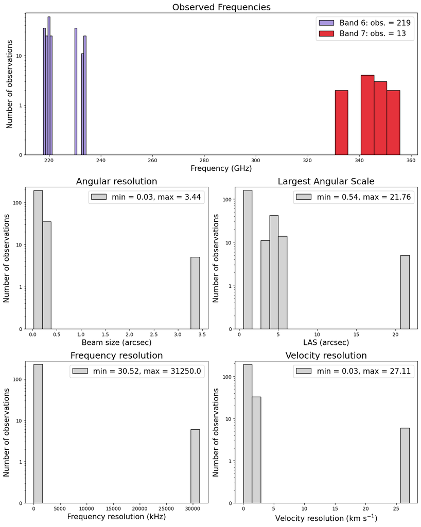

```python
alminer.plot_overview(q_results, showfig=True)
```

### Print all columns

```python
print(q_results.columns)

# Get information about the columns of interest
alminer.get_info('ang_res_arcsec')
alminer.get_info('vel_res_kms')
```

```
Index(['Obs', 'project_code', 'ALMA_source_name', 'RAJ2000', 'DEJ2000',
       'ang_res_arcsec', 'min_freq_GHz', 'max_freq_GHz', 'central_freq_GHz',
       'bandwidth_GHz', 'freq_res_kHz', 'vel_res_kms', 'LAS_arcsec',
       'FoV_arcsec', 'cont_sens_bandwidth', 'line_sens_10kms',
       'line_sens_native', 'MOUS_id', 'obs_publisher_did', 'obs_collection',
       'facility_name', 'instrument_name', 'obs_id', 'dataproduct_type',
       'calib_level', 'collections', 'target_name', 's_ra', 's_dec', 's_fov',
       's_region', 's_xel1', 's_xel2', 'em_xel', 't_xel', 'pol_xel',
       's_resolution', 't_min', 't_max', 't_exptime', 't_resolution', 'em_min',
       'em_max', 'em_res_power', 'pol_states', 'cont_sensitivity_bandwidth',
       'pwv', 'group_ous_uid', 'member_ous_uid', 'asdm_uid', 'obs_title',
       'type', 'scan_intent', 'science_observation', 'spatial_scale_max',
       'qa2_passed', 'bib_reference', 'science_keyword', 'scientific_category',
       'pi_userid', 'pi_name', 'spectral_resolution', 'o_ucd', 'access_url',
       'access_format', 'access_estsize', 'proposal_id', 'data_rights',
       'gal_longitude', 'gal_latitude', 'band_list', 'em_resolution',
       'bandwidth', 'antenna_arrays', 'is_mosaic', 'obs_release_date',
       'spatial_resolution', 'frequency_support', 'frequency',
       'velocity_resolution', 'obs_creator_name', 'pub_title', 'first_author',
       'authors', 'pub_abstract', 'publication_year', 'proposal_abstract',
       'schedblock_name', 'proposal_authors', 'sensitivity_10kms',
       'lastModified'],
      dtype='object')
--------------------------------
Column: ang_res_arcsec
--------------------------------
Description: typical spatial resolution
Units: arcsec
--------------------------------
--------------------------------
Column: vel_res_kms
--------------------------------
Description: Velocity resolution of the subband in km/s
Units: km/s
--------------------------------
```

### Print the summary of an subquery

#### Angular Resolution < 3 arcsec, Velocity Resolution < 60 km/s

```python
sub_query = q_results[(q_results['ang_res_arcsec'] < 3) &
                    (q_results['vel_res_kms'] < 60.0)]
alminer.summary(sub_query, print_targets=True)
```

```
--------------------------------
Number of projects = 3
Number of observations = 38
Number of unique subbands = 26
Total number of subbands = 227
28 target(s) with ALMA data = ['L1489IRS', 'IRAS04166+2706', 'IRAS04302+2247', 'BHR71_IRS2', 'IRAS15398-3559', 'OphIRS43', 'IRAS32', 'GSS30IRS3', 'L1527IRS', 'Ced110IRS4', 'CB68', 'IRS5N', 'BHR71_IRS1', 'IRAS16253-2429', 'IRS7B', 'IRAS04169+2702', 'Elias_2-24', '2MASS_J16120668-3010270', '2MASS_J161…
--------------------------------
```

### Plot the overview of the subquery

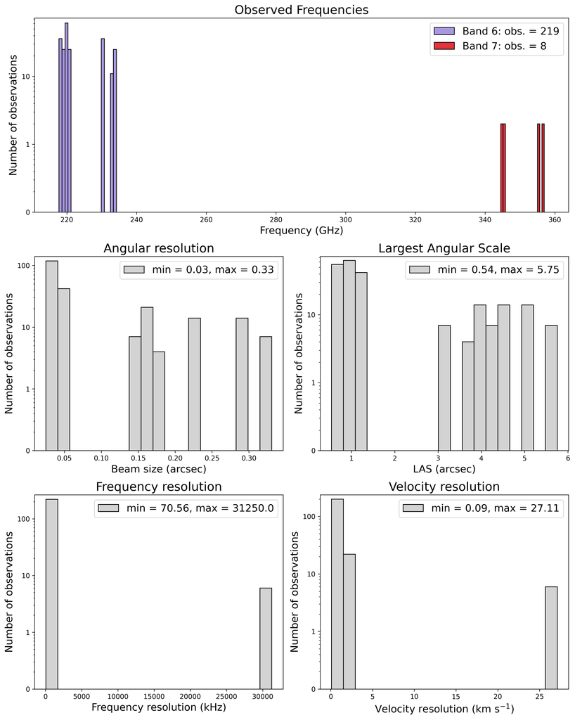

```python
alminer.plot_overview(sub_query) # you can also specify a redshift using the 'z' parameter (default=0)
```

## Query CO lines

### Search whether any CO lines are covered in the above observations:

Note that if you are interested in observations of targets at high-redshift, you can specify a redshift using the 'z' parameter.

```python
CO_obs = alminer.CO_lines(q_results, z=0)
```

```
--------------------------------
Summary of 'CO (1-0)' observations at 115.271 GHz
--------------------------------
No observations found.
--------------------------------
--------------------------------
Summary of 'CO (2-1)' observations at 230.538 GHz
--------------------------------
Number of projects = 2
Number of observations = 36
Number of unique subbands = 3
Total number of subbands = 36
27 target(s) with ALMA data = ['IRAS04166+2706', 'IRAS04302+2247', 'BHR71_IRS2', 'IRAS15398-3559', 'OphIRS43', 'IRAS32', 'GSS30IRS3', 'L1527IRS', 'Ced110IRS4', 'CB68', 'IRS5N', 'BHR71_IRS1', 'IRAS16253-2429', 'IRS7B', 'IRAS04169+2702', 'L1489IRS', '2MASS_J16145024-2100599', '2MASS_J16140792-1938292'…
--------------------------------
--------------------------------
Summary of 'CO (3-2)' observations at 345.796 GHz
--------------------------------
Number of projects = 2
Number of observations = 3
Number of unique subbands = 2
Total number of subbands = 3
2 target(s) with ALMA data = ['Elias_2-24', 'hd_163296']
--------------------------------
--------------------------------
Summary of 'CO (4-3)' observations at 461.041 GHz
--------------------------------
No observations found.
--------------------------------
--------------------------------
Summary of 'CO (5-4)' observations at 576.268 GHz
--------------------------------
No observations found.
--------------------------------
--------------------------------
Summary of 'CO (6-5)' observations at 691.473 GHz
--------------------------------
No observations found.
--------------------------------
--------------------------------
Summary of 'CO (7-6)' observations at 806.652 GHz
```

[output cut: 85 more lines]

```
--------------------------------
Summary of 'C18O (6-5)' observations at 658.553 GHz
--------------------------------
No observations found.
--------------------------------
--------------------------------
Summary of 'C18O (7-6)' observations at 768.252 GHz
--------------------------------
No observations found.
--------------------------------
--------------------------------
Summary of 'C18O (8-7)' observations at 877.922 GHz
--------------------------------
No observations found.
--------------------------------
```

### Mark redshifted CO lines:

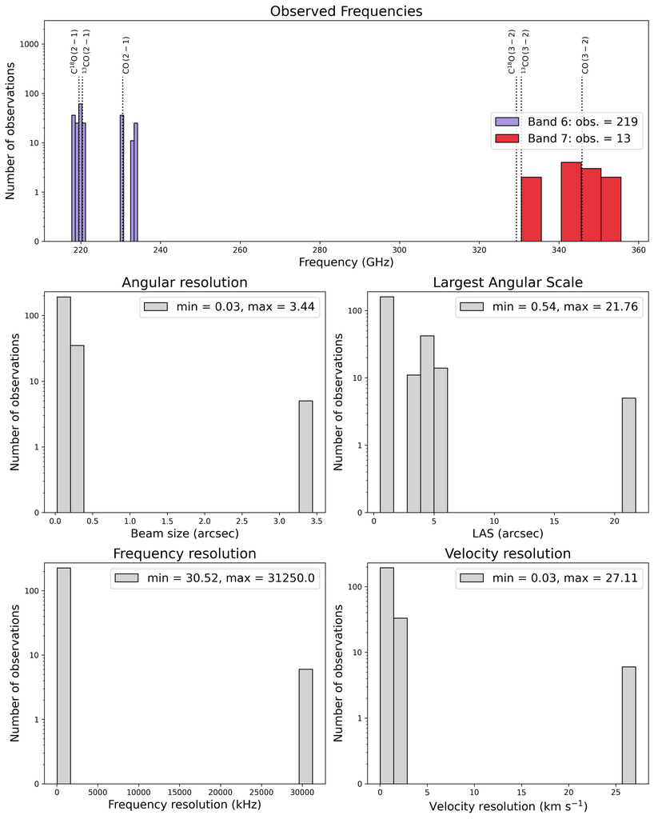

```python
alminer.plot_overview(q_results, mark_CO=True)
```

### Search whether a given frequency is covered in the observations:

```python
myline_obs = alminer.line_coverage(q_results,
                                   line_freq=330.588,
                                   z=0,
                                   line_name="CO 3-2",
                                   print_targets=True)
```

```
--------------------------------
Summary of 'CO 3-2' observations at 330.588 GHz
--------------------------------
Number of projects = 1
Number of observations = 1
Number of unique subbands = 1
Total number of subbands = 1
1 target(s) with ALMA data = ['hd_163296']
--------------------------------
```

### Highlight this frequency in the overview plots:

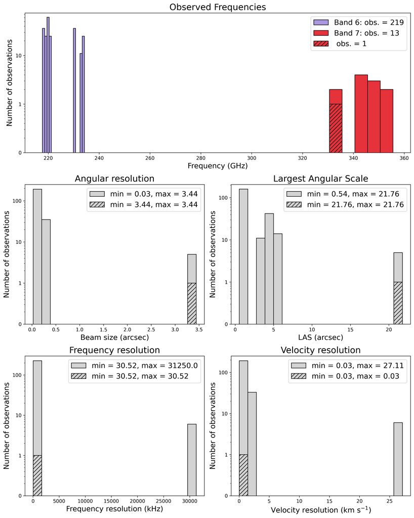

```python
alminer.plot_line_overview(q_results, line_freq=330.588)
```

## Download all data products (raw + products)

```python
alminer.download_data(myline_obs, fitsonly=False, dryrun=True,
                      location='./data', print_urls=False)
```

```
================================
This is a dryrun. To begin download, set dryrun=False.
================================
Download location = data
Total number of Member OUSs to download = 1
Selected Member OUSs: ['uid://A001/X3621/Xc49']
Number of files to download = 5
Needed disk space = 13.9 GB
--------------------------------
```

### Download only continuum FITS images:

```python
alminer.download_data(myline_obs, fitsonly=True, dryrun=True,
                      location='./data', print_urls=True,
                      filename_must_include=['_sci', '.pbcor', 'cont'])
```

```
================================
This is a dryrun. To begin download, set dryrun=False.
================================
Download location = data
Total number of Member OUSs to download = 1
Selected Member OUSs: ['2023.1.01438.S_uid___A001_X3621_Xc49_001_of_001.tar']
Number of files to download = 3
Needed disk space = 198.7 KB
File URLs to download = https://almascience.eso.org/dataPortal/member.uid___A001_X3621_Xc49.hd_163296_sci.spw16_18_20_22_24.cont.I.pbcor.fits
https://almascience.eso.org/dataPortal/member.uid___A001_X3621_Xc49.hd_163296_sci.spw16_18_20_22_24.cont.I.selfcal.tt0.pbcor.fits
https://almascience.eso.org/dataPortal/member.uid___A001_X3621_Xc49.hd_163296_sci.spw16_18_20_22_24.cont.I.selfcal.tt1.pbcor.fits
--------------------------------
```

## Send a pyVO query using ALminer

We can use all the analysis and plotting routines presented before on these observations:

```python
query_str = f"""SELECT *
                 FROM ivoa.ObsCore
                 WHERE frequency > 300
                 AND frequency < 400
                 AND sensitivity_10kms < 5
                 AND science_keyword LIKE '%disk%'
            """

q_results = alminer.run_query(query_str)
q_results_obs = alminer.filter_results(q_results, print_targets=False)
```

```
--------------------------------
Number of projects = 54
Number of observations = 740
Number of unique subbands = 648
Total number of subbands = 2980
Total number of targets with ALMA data = 495
--------------------------------
```

## Final Task: retrieve useful fits for the next steps

#### 1: hd142527, Band 3, 2018.1.00568.S, full Stokes

#### 2: hd142527, Band 7, 2015.1.00425.S, Stokes I

```python
q_results = alminer.target('hd142527')
sub_query = q_results[(q_results['proposal_id'] == '2018.1.00568.S') &
                    (q_results['band_list'] == '3')
                ]
alminer.download_data(sub_query, fitsonly=True, dryrun=True,
                      location='./data', print_urls=True,
                      filename_must_include=['hd142527','IQUV', 'mfs'])
```

```
================================
alminer.target results
================================
Target = hd142527
--------------------------------
Number of projects = 18
Number of observations = 34
Number of unique subbands = 134
Total number of subbands = 168
6 target(s) with ALMA data = ['HD 142527', 'HD_142527', 'hd142527', 'Hd_142527', 'HD142527', 'hd_142527']
--------------------------------
================================
This is a dryrun. To begin download, set dryrun=False.
================================
Download location = data
Total number of Member OUSs to download = 1
Selected Member OUSs: ['2018.1.00568.S_uid___A001_X133d_Xf67_001_of_001.tar']
Number of files to download = 1
Needed disk space = 25.4 MB
File URLs to download = https://almascience.eso.org/dataPortal/member.uid___A001_X133d_Xf67.hd142527_sci.spw13_15_17_19.mfs.IQUV.manual.pbcor.fits
--------------------------------
```

```python
q_results = alminer.target('hd142527')
sub_query = q_results[(q_results['proposal_id'] ==  '2015.1.00425.S') &
                    (q_results['band_list'] == '7')]
alminer.download_data(sub_query, fitsonly=True, dryrun=True,
                      location='./data', print_urls=True,
                      filename_must_include=['StokesI'])
```

```
================================
alminer.target results
================================
Target = hd142527
--------------------------------
Number of projects = 18
Number of observations = 34
Number of unique subbands = 134
Total number of subbands = 168
6 target(s) with ALMA data = ['HD 142527', 'HD_142527', 'hd142527', 'Hd_142527', 'HD142527', 'hd_142527']
--------------------------------
================================
This is a dryrun. To begin download, set dryrun=False.
================================
Download location = data
Total number of Member OUSs to download = 2
Selected Member OUSs: ['2015.1.00425.S_uid___A001_X2fe_X640_001_of_001.tar', '2015.1.00425.S_uid___A001_X2fe_X63e_001_of_001.tar']
Number of files to download = 3
Needed disk space = 12.0 MB
File URLs to download = https://almascience.eso.org/dataPortal/member.uid___A001_X2fe_X640.concat.ms.clean.field5.StokesI.pbcor.fits
https://almascience.eso.org/dataPortal/member.uid___A001_X2fe_X63e.concat.ms.cal.clean.field2.spwAll.br0.pb.StokesI.fits
https://almascience.eso.org/dataPortal/member.uid___A001_X2fe_X63e.concat.ms.cal.clean.field2.spwAll.br0.pbcor.StokesI.fits
--------------------------------
```

# Extra exercises

```python
query = """
        SELECT *
        FROM ivoa.ObsCore
        WHERE target_name = 'HL Tau'
        AND (frequency - 0.5 * bandwidth/1e9) < 120
        AND (frequency + 0.5 * bandwidth/1e9) > 100
        AND t_exptime >= 12000
        """

q_results = service.search(query).to_table().to_pandas()
q_results
```

|  | obs_publisher_did | obs_collection | facility_name | instrument_name | obs_id | dataproduct_type | calib_level | collections | target_name | s_ra | s_dec | s_fov | s_region | s_xel1 | s_xel2 | em_xel | t_xel | pol_xel | s_resolution | t_min | t_max | t_exptime | t_resolution | em_min | em_max | em_res_power | pol_states | cont_sensitivity_bandwidth | pwv | … |
| --- | --- | --- | --- | --- | --- | --- | --- | --- | --- | --- | --- | --- | --- | --- | --- | --- | --- | --- | --- | --- | --- | --- | --- | --- | --- | --- | --- | --- | --- | --- |
| 0 | ADS/JAO.ALMA#2011.0.00015.SV | ALMA | JAO | ALMA | uid://A002/X8fa7af/X1e.source.HL Tau.spw.13 | image | 2 |  | HL Tau | 67.91011 | 18.232513 | 0.016822 | Polygon ICRS 67.918343 18.235609 67.918965 18.... | <NA> | <NA> | 128 | 1 | 2 | 0.070851 | 56944.285874 | 56974.298741 | 12700.291 | 12700.291 | 0.002945 | 0.003003 | 3257.7236 | /XX/YY/ | 0.015984 | 1.070972 | … |
| 1 | ADS/JAO.ALMA#2011.0.00015.SV | ALMA | JAO | ALMA | uid://A002/X8fa7af/X1e.source.HL Tau.spw.15 | image | 2 |  | HL Tau | 67.91011 | 18.232513 | 0.016822 | Polygon ICRS 67.918343 18.235609 67.918965 18.... | <NA> | <NA> | 128 | 1 | 2 | 0.070851 | 56944.285874 | 56974.298741 | 12700.291 | 12700.291 | 0.002890 | 0.002946 | 3319.7500 | /XX/YY/ | 0.015984 | 1.070972 | … |

```python
q_results = alma.query_object("TW Hydra", payload = dict(
            spatial_resolution = "0.1..0.5"))


q_results = q_results[[datetime.fromisoformat(i) > datetime(2018,1,1)
                       for i in q_results['obs_release_date']]]

CO_21_loc = np.array([any([a[0] < q_row['frequency'] * u.GHz < a[1]
            for a in parse_frequency_support(q_row['frequency_support'])
            if a[0] < 230.538 * u.GHz < a[1]])
            for q_row in q_results]).T

q_results = q_results[CO_21_loc]

q_results.to_pandas()
```

|  | obs_publisher_did | obs_collection | facility_name | instrument_name | obs_id | dataproduct_type | calib_level | collections | target_name | s_ra | s_dec | s_fov | s_region | s_xel1 | s_xel2 | em_xel | t_xel | pol_xel | s_resolution | t_min | t_max | t_exptime | t_resolution | em_min | em_max | em_res_power | pol_states | cont_sensitivity_bandwidth | pwv | … |
| --- | --- | --- | --- | --- | --- | --- | --- | --- | --- | --- | --- | --- | --- | --- | --- | --- | --- | --- | --- | --- | --- | --- | --- | --- | --- | --- | --- | --- | --- | --- |
| 0 | ADS/JAO.ALMA#2016.1.00311.S | ALMA | JAO | ALMA | uid://A001/X87a/X75d.source.TW_Hya.spw.37 | cube | 2 | ari_l | TW_Hya | 165.465885 | -34.704798 | 0.00723 | Polygon ICRS 165.468003 -34.701631 165.469273 ... | <NA> | <NA> | 3840 | 1 | 2 | 0.279700 | 57878.946775 | 57880.070099 | 4777.825 | 4777.825 | 0.001298 | 0.001303 | 4.711381e+05 | /XX/YY/ | 0.029724 | 1.201756 | … |
| 1 | ADS/JAO.ALMA#2018.A.00021.S | ALMA | JAO | ALMA | uid://A001/X138b/X54.source.TW_Hya.spw.25 | cube | 2 |  | TW_Hya | 165.465818 | -34.704806 | 0.00686 | Polygon ICRS 165.469786 -34.703746 165.469982 ... | <NA> | <NA> | 3840 | 1 | 2 | 0.131159 | 58755.537403 | 58755.777623 | 11975.016 | 11975.016 | 0.001300 | 0.001301 | 7.554939e+06 | /XX/YY/ | 0.021206 | 0.647280 | … |

```python
q_results = alminer.target('DM Tau')
sub_query = q_results[(q_results['ang_res_arcsec'] < 0.1) &
                    (q_results['band_list'] == '6') &
                    (q_results['spatial_scale_max'] > 0.49) &
                    (q_results['sensitivity_10kms'] > 0.44)
                    ]

alminer.explore(sub_query, allcols=True, allrows=False).head()
```

```
================================
alminer.target results
================================
Target = DM Tau
--------------------------------
Number of projects = 20
Number of observations = 33
Number of unique subbands = 135
Total number of subbands = 153
5 target(s) with ALMA data = ['DM_Tau', 'DM_tau', 'DM Tau', 'dm_tau', 'DMTau']
--------------------------------
```

|  | Obs | project_code | ALMA_source_name | RAJ2000 | DEJ2000 | ang_res_arcsec | min_freq_GHz | max_freq_GHz | central_freq_GHz | bandwidth_GHz | freq_res_kHz | vel_res_kms | LAS_arcsec | FoV_arcsec | cont_sens_bandwidth | line_sens_10kms | line_sens_native | MOUS_id | obs_publisher_did | obs_collection | facility_name | instrument_name | obs_id | dataproduct_type | calib_level | collections | target_name | s_ra | s_dec | … |
| --- | --- | --- | --- | --- | --- | --- | --- | --- | --- | --- | --- | --- | --- | --- | --- | --- | --- | --- | --- | --- | --- | --- | --- | --- | --- | --- | --- | --- | --- | --- |
| 85 | 86 | 2017.1.01460.S | dm_tau | 68.453056 | 18.169351 | 0.026 | 230.5 | 230.62 | 230.56 | 0.117 | 70.56 | 0.092 | 0.499 | 25.899 | 17.163 | 445.58 | 114.17 | uid://A001/X1284/X230b | ADS/JAO.ALMA#2017.1.01460.S | ALMA | JAO | ALMA | uid://A001/X1284/X230b.source.dm_tau.spw.25 | cube | 2 |  | dm_tau | 68.453056 | 18.169351 | … |